# Crime Analytics: Visualization of Crime Incident Reports for Summar 2014 in San Francisco and Seattle

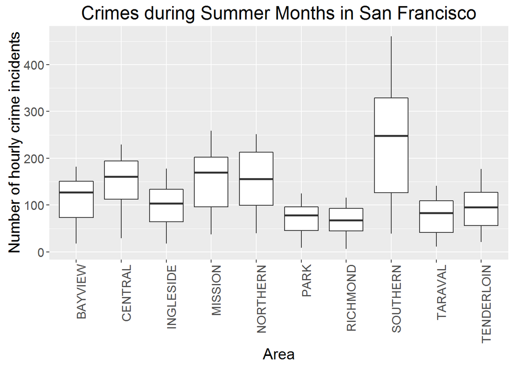

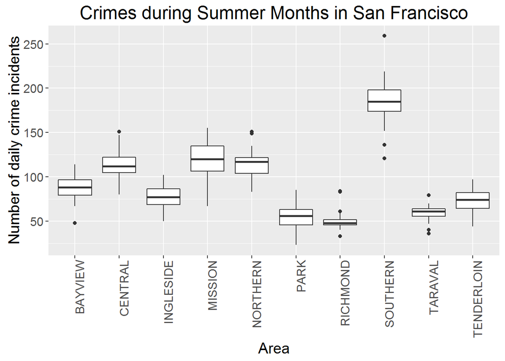

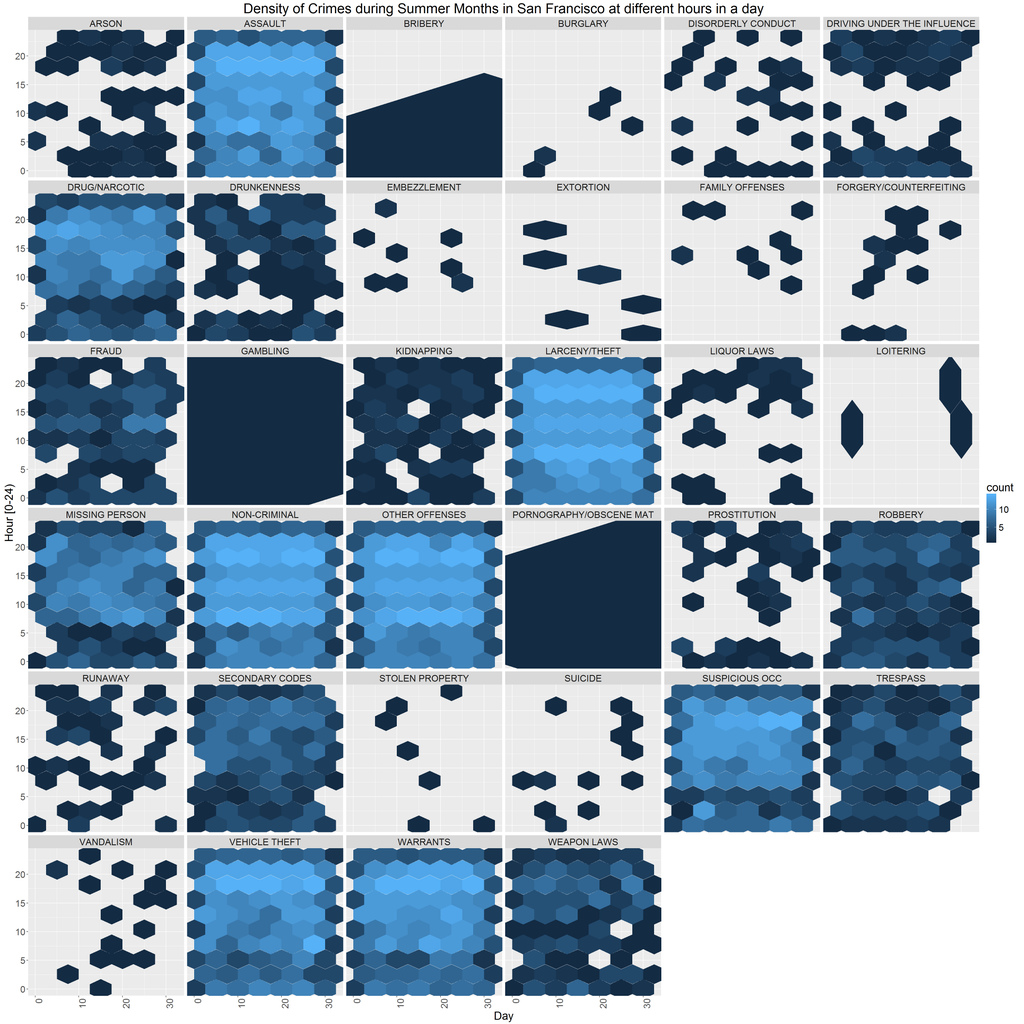

### As can be seen from the next visualization, most of the crimes (more than $60\%$) in San Francisco, there were no resolution, whereas just over $20\%$ of the cases there were arrests.

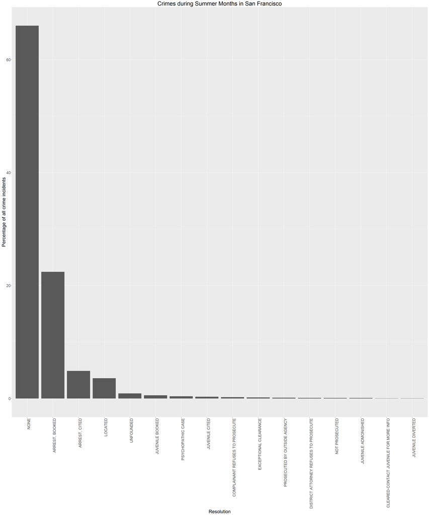

### As can be seen from the next visualization, the highest number of arrest, booked resolution in San Francisco was for crime category WARRANT.

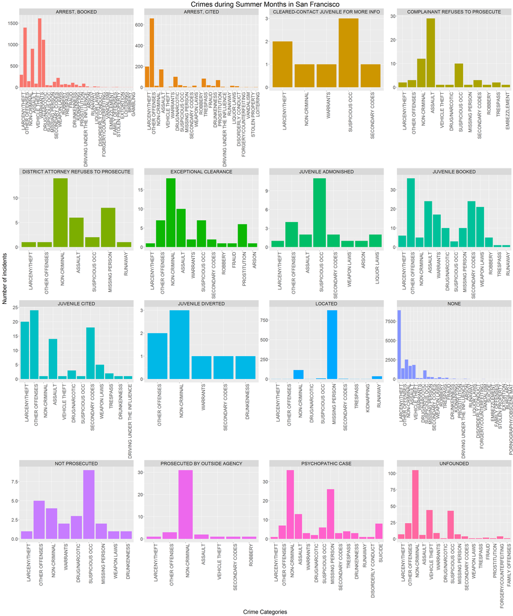

### As can be seen from the next visualization, most of the resolutions (such as arrest booked/cited) in San Francisco belong to SOUTHERN area (where most of the crimes happened, as seen earlier), but the highest number of unresolved cases belong to the same area as well. The higest number of JUVENILE BOOED resolution taken was in BAYVIEW, where the maximum number of EXCEPTIONAL CLEARANCE resolution was for TARVAL.

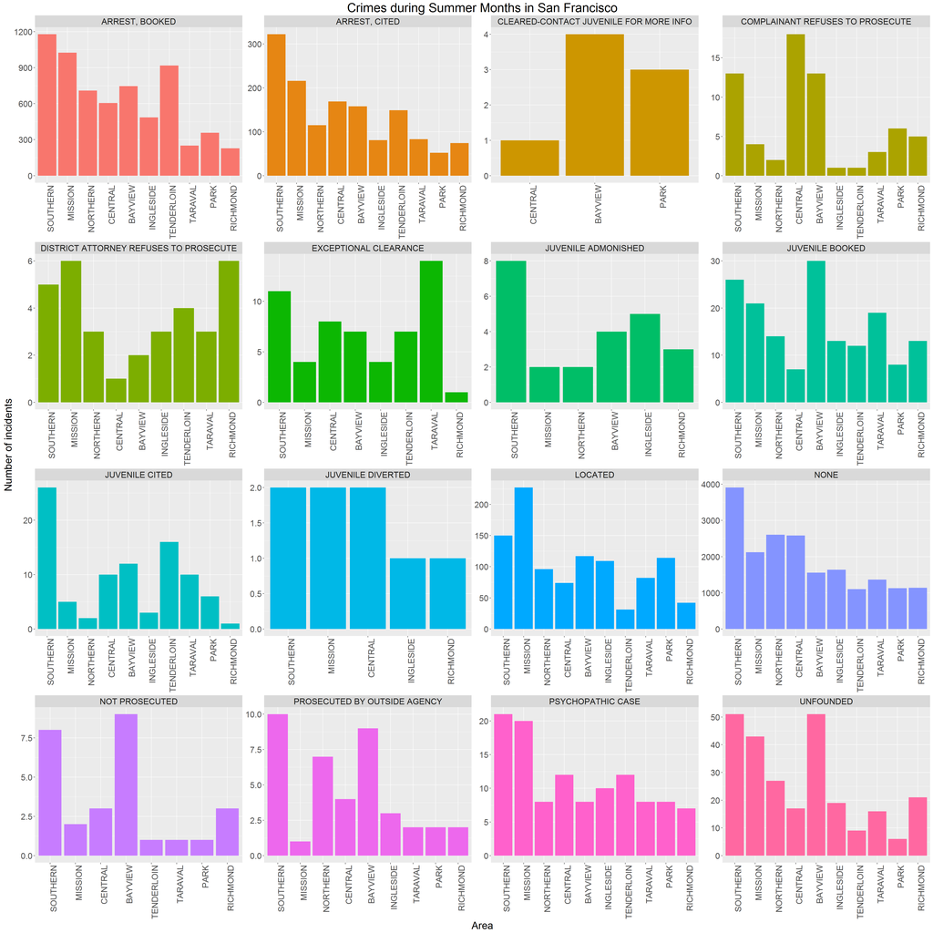

### The following (Heatmap) visualization shows that (w.r.t. the total number of incidents count) 3 AM - 7 AM is the safest time in San Francisco during the summer months.

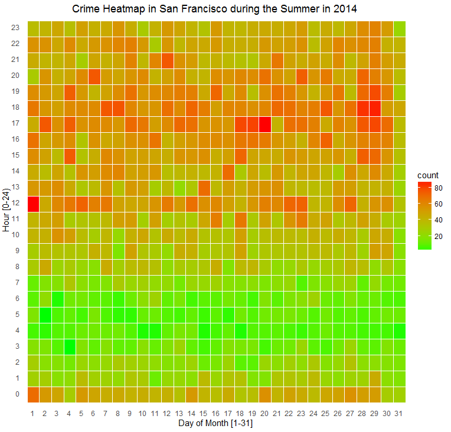

### The following (Heatmap) visualization shows that (w.r.t. the total number of incidents) 1 AM - 11 AM is the safest time in the University District of Seattle during the summer months.

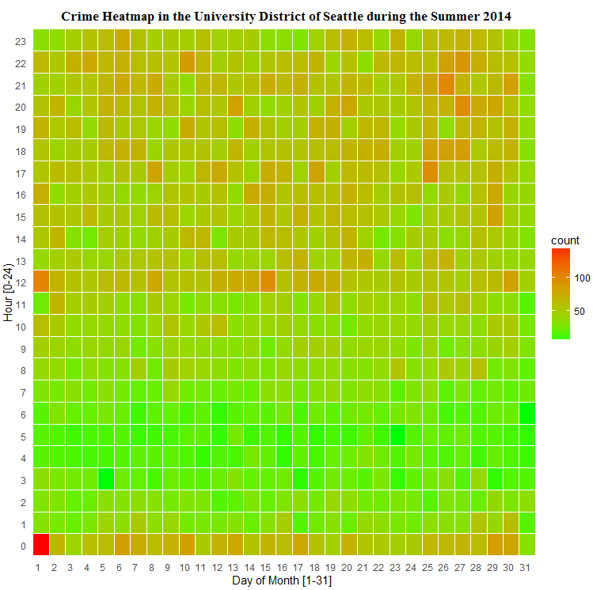

### The following visualization shows the spatial patterns (w.r.t. the total number of incidents) for a few different types of crimes in San Francisco during the summer months.

[figure not shown]

### The following visualization shows the spatial patterns (w.r.t. the total number of incidents) for a few different types of crimes in the University District of Seattle during the summer months.

[figure not shown]

### The following visualization shows how the crime patrerns changed over months in the University District of Seattle during the summer months.

[figure not shown]

### The following visualization (Contour) shows that the most of the crimes happened in the region Tenderloin and Market St (w.r.t. the total number of incidents) in San Francisco during the summer months.

[figure not shown]

### The following visualization (Contour) shows that the most of the crimes happened in the region WesteLake Center, Union Street and PIKEPLACE Market (w.r.t. the total number of incidents) in the University District of Seattle during the summer months.

[figure not shown]